# GMU20

Li Ma

1/27/2022

## Loading necessary libraries

Loading necessary libraries.

```
## ✖ lubridate::%within%() masks IRanges::%within%()
## ✖ lubridate::second<-() masks S4Vectors::second<-()
```

## Setting ups

Basic set ups

```
## Allowing multi-threading with up to 48 threads.
```

```
##  [1] "samples.txt" "SRR7702228"  "SRR7702229"  "SRR7702230"  "SRR7702231"
##  [6] "SRR7702232"  "SRR7702233"  "SRR7702234"  "SRR7702235"  "SRR7702236"
## [11] "SRR7702237"  "SRR7702238"  "SRR7702239"  "SRR7702240"  "SRR7702241"
## [16] "SRR7702242"  "SRR7702243"  "SRR7702244"  "SRR7702245"  "SRR7702246"
## [21] "SRR7702247"  "SRR7702248"  "SRR7702249"  "SRR7702250"  "SRR7702251"
## [26] "SRR7702252"  "SRR7702253"  "SRR7702254"  "SRR7702255"  "SRR7702256"
## [31] "SRR7702257"  "SRR7702258"  "SRR7702259"  "SRR7702260"  "SRR7702261"
## [36] "SRR7702262"  "SRR7702263"  "SRR7702264"  "SRR7702265"
```

## Take out the tables and exame the data quality

Take out the tables we need from the RSQLite database

|  | id | condition | shortname | pca_name | data_color |
| --- | --- | --- | --- | --- | --- |
| 1 | SRR7702228 | MSC | MSC1_1 | MSC1_1 | blue |
| 2 | SRR7702229 | MSC | MSC1_2 | MSC1_2 | blue |
| 3 | SRR7702230 | MSC | MSC1_3 | MSC1_3 | blue |
| 4 | SRR7702231 | MSC | MSC2_1 | MSC2_1 | blue |
| 5 | SRR7702232 | MSC | MSC2_2 | MSC2_2 | blue |
| 6 | SRR7702233 | MSC | MSC2_3 | MSC2_3 | blue |
| 7 | SRR7702234 | MSC | MSC3_1 | MSC3_1 | blue |
| 8 | SRR7702235 | MSC | MSC3_2 | MSC3_2 | blue |
| 9 | SRR7702236 | MSC | MSC3_3 | MSC3_3 | blue |
| 10 | SRR7702237 | MSC | MSC4_1 | MSC4_1 | blue |

[output cut: 28 more lines]

```
## reading in files with read_tsv
```

```
## 1 2 3 4 5 6 7 8 9 10 11 12 13 14 15 16 17 18 19 20 21 22 23 24 25 26 27 28 29 30 31 32 33 34 35 36 37 38
## summarizing abundance
## summarizing counts
## summarizing length
```

Plot out the raw data

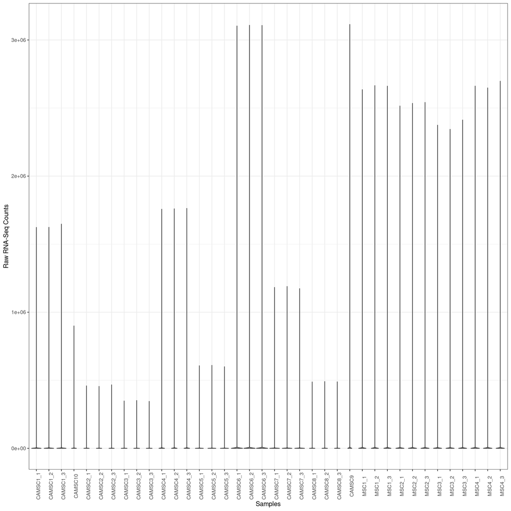

```
## [1] "Modes: character, NULL"
## [2] "Lengths: 38, 0"
## [3] "target is character, current is NULL"
```

Prepare the data set for DESeq2. Genes with counts lower than 10 are removed. Then, plot the processed data set.

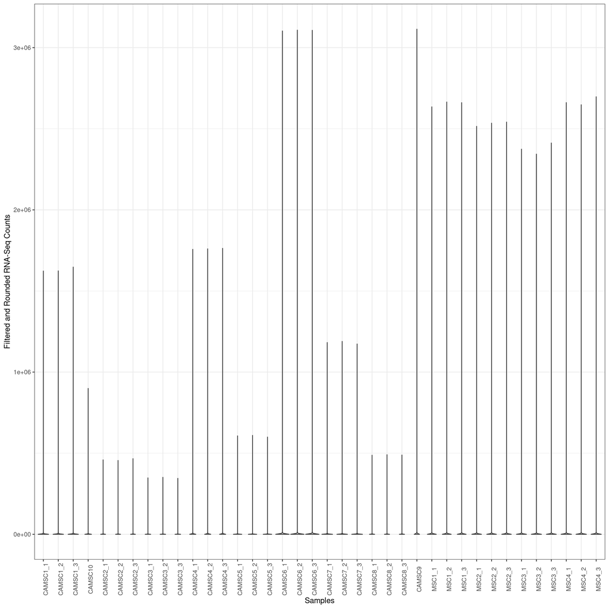

## Normalize the data set using DESeq2

Create a DESeqDataSet object from the matrix. Then, normalize the count matrix using the varianceStabilizingTransformation() function

```
## using counts and average transcript lengths from tximport
```

```
## [1] 36680
```

```
## using 'avgTxLength' from assays(dds), correcting for library size
```

```
## using 'avgTxLength' from assays(dds), correcting for library size
```

```
## -- replacing outliers and refitting for 5367 genes
## -- DESeq argument 'minReplicatesForReplace' = 7
## -- original counts are preserved in counts(dds)
```

Check the data quality and remove the low quality genes if necessary.

```
##  Flagging genes and samples with too many missing values...
##   ..step 1
##   ..Excluding 1830 genes from the calculation due to too many missing samples or zero variance.
##   ..step 2
```

## Find out a proper power

Run the pickSoftThreshold() function and plot out the powers to find out the proper power.

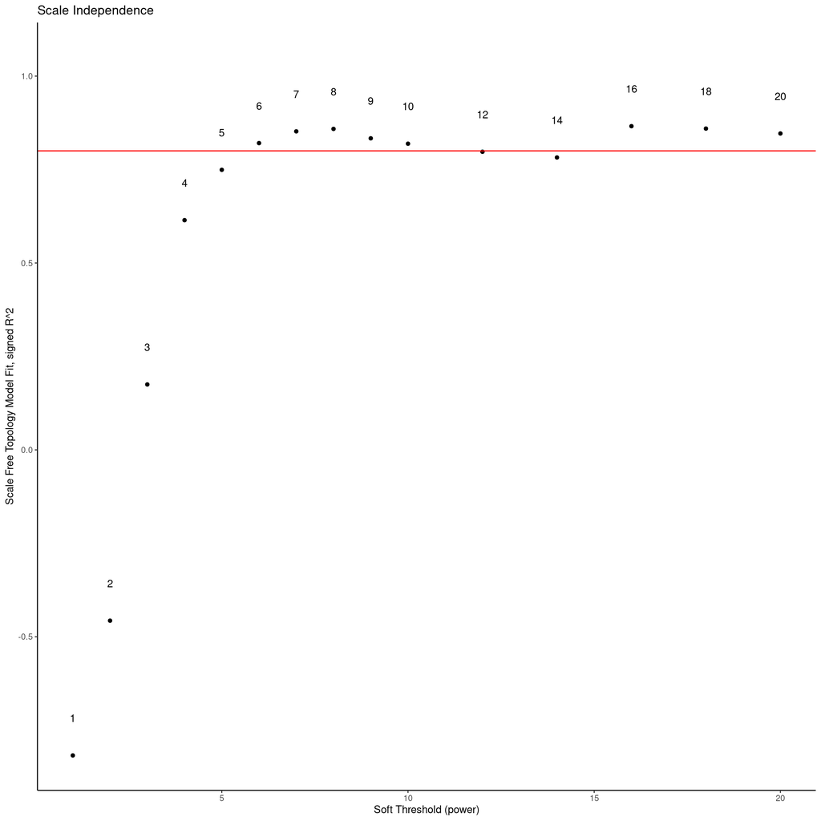

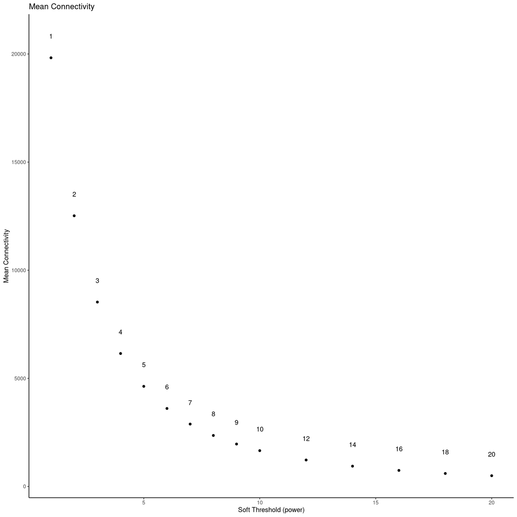

## Run WGCNA

Run WGCNA, using its blockwiseModules() function

```
##
##     0     1     2     3     4     5     6     7     8     9    10    11    12
##  2523 15326  1897  1716  1342  1342  1050  1029   955   748   610   593   563
##    13    14    15    16    17    18    19    20    21    22    23    24    25
##   548   544   527   467   433   421   272   255   210   190   156   144   106
##    26    27    28    29    30    31    32    33    34    35    36    37    38
##    83    64    61    59    59    53    44    37    37    36    35    34    33
##    39    40    41    42    43    44    45    46    47
##    33    32    30    30    27    27    26    22    21
```

Plot the dendrogram and the module colors

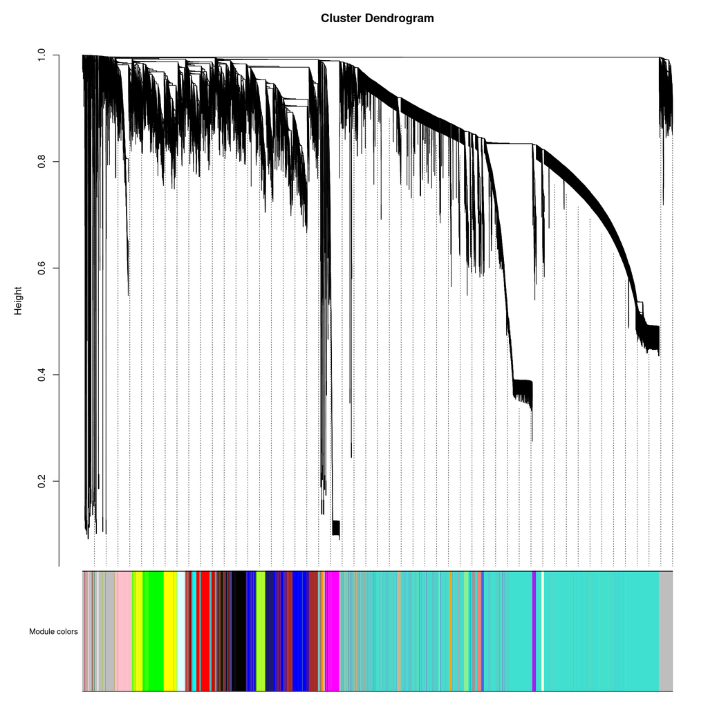

Plot out the module-sample relationships

```
##           gene_id       colors
## 1 ENSG00000000003       yellow
## 2 ENSG00000000005    turquoise
## 3 ENSG00000000419 midnightblue
## 4 ENSG00000000457        brown
## 5 ENSG00000000460         pink
```

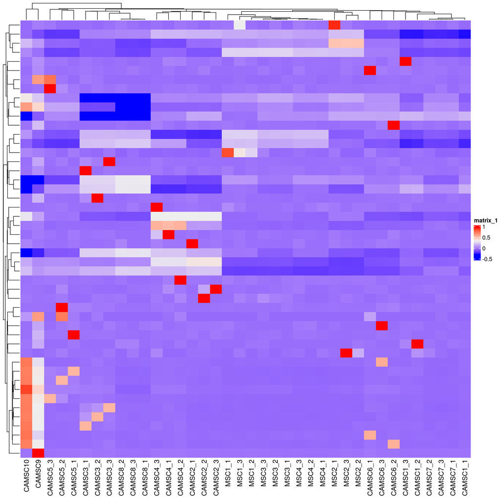

## Take out the modular eigengenes and define a function for plot heatmap

```
##               ME29        ME26         ME28         ME8        ME22         ME3
## MSC1_1 -0.03021995 -0.03816434 -0.002769947  0.24240375  0.19626558 -0.01711064
## MSC1_2 -0.04180373 -0.02559277 -0.025476445  0.24252575  0.19686299 -0.01423545
## MSC1_3 -0.02451940 -0.03766282 -0.041358588  0.24474642  0.19288257 -0.01773781
## MSC2_1 -0.04058343 -0.03063741 -0.038913003 -0.09392635 -0.04079632 -0.11211786
## MSC2_2 -0.04146453 -0.03960433 -0.027683192 -0.08957708 -0.04425717 -0.11008234
## MSC2_3 -0.04167077 -0.03264893 -0.017421500 -0.09110469 -0.03680093 -0.11073991
##              ME11        ME15         ME47        ME43        ME39         ME32
## MSC1_1 0.07354286 -0.02790598 -0.038798611 -0.04346439 -0.03983634 -0.004561019
## MSC1_2 0.07211934 -0.03081005 -0.038798611 -0.01367862 -0.04329866 -0.013087236
## MSC1_3 0.07534556 -0.02553594 -0.021541655  0.01054918 -0.03243896 -0.023605403
## MSC2_1 0.04023598 -0.12314337 -0.008067383 -0.03548278 -0.03028132 -0.022553921
## MSC2_2 0.04499927 -0.12810083 -0.038798611 -0.03070354 -0.03924814 -0.017864394
## MSC2_3 0.04499661 -0.12293779 -0.024173991 -0.01162429 -0.03804687 -0.023442647
##                ME40        ME38        ME5       ME14         ME6        ME21
## MSC1_1  0.038935419 -0.03195326 -0.1699746 -0.1239491 -0.05485033 -0.06055568
## MSC1_2 -0.037601549 -0.04307111 -0.1723499 -0.1272643 -0.05776955 -0.05917797
## MSC1_3 -0.004874591 -0.02195734 -0.1749294 -0.1265271 -0.05405024 -0.05831923
## MSC2_1 -0.009836313 -0.01177901 -0.1722452 -0.1767020 -0.01060387 -0.10209589
## MSC2_2 -0.016968831 -0.04307111 -0.1737658 -0.1790464 -0.01354403 -0.10216420
## MSC2_3 -0.037601549 -0.03581455 -0.1735970 -0.1800767 -0.01104458 -0.09686828
##                ME35        ME30        ME37        ME27        ME34        ME41
## MSC1_1 -0.007068282 -0.02510174 -0.01318690 -0.03243902 -0.04668955 -0.02400505
## MSC1_2 -0.043497150 -0.03755545 -0.04380076 -0.01667288 -0.04668955 -0.03090407
## MSC1_3 -0.035607328 -0.04289875 -0.02339427 -0.02628450 -0.03728565 -0.03090793
## MSC2_1 -0.028427013 -0.04012890 -0.04380076 -0.02780095 -0.03692973 -0.02860510
## MSC2_2 -0.043497150 -0.03776240 -0.03513805 -0.03183949 -0.04668955 -0.03593211
## MSC2_3 -0.043497150 -0.04289875 -0.03352747 -0.02827375 -0.02963691 -0.03593211
##               ME44         ME9        ME2         ME12        ME25        ME24
## MSC1_1 -0.05112931 -0.02797344 0.07839500 -0.004117704 -0.04480999 -0.05170150
## MSC1_2 -0.05112931 -0.02506723 0.07509417 -0.007317290 -0.04454304 -0.04882935
## MSC1_3 -0.05112931 -0.02794380 0.07657607 -0.007698712 -0.04659688 -0.04543317
## MSC2_1 -0.05112931 -0.02951199 0.13839052  0.033884801 -0.04853261 -0.04447270
## MSC2_2 -0.05112931 -0.02666790 0.13475997  0.037631720 -0.04646566 -0.04790079
## MSC2_3 -0.05112931 -0.02554045 0.13722645  0.041928958 -0.04789781 -0.04339658
##               ME23        ME10        ME18         ME1        ME13        ME19
## MSC1_1 -0.04857496 -0.05262615 -0.05449363 -0.04373650 -0.05465328 -0.04909165
## MSC1_2 -0.04707108 -0.05745358 -0.05495500 -0.04276372 -0.05772072 -0.05104423
## MSC1_3 -0.04534835 -0.05632475 -0.05020891 -0.04447558 -0.05390102 -0.05175900
## MSC2_1 -0.05082107 -0.05890095 -0.05540067 -0.04404522 -0.05869688 -0.05416287
## MSC2_2 -0.05324683 -0.05879827 -0.05708163 -0.04387749 -0.05530471 -0.03958409
## MSC2_3 -0.04204533 -0.05822582 -0.05278660 -0.04229910 -0.05642729 -0.05794243
##               ME17        ME20        ME36        ME46         ME45       ME4
## MSC1_1 -0.05853646 -0.05263936  0.85031433 -0.05086490 -0.021566950 0.2495124
## MSC1_2 -0.05253564 -0.04975083  0.25412350 -0.05086490 -0.037027007 0.2457273
## MSC1_3 -0.05081624 -0.05221542  0.35953846 -0.01390211  0.326953658 0.2467443
## MSC2_1 -0.05675315 -0.05687315 -0.01474372 -0.03459213  0.916937263 0.1998921
## MSC2_2 -0.05872591 -0.05598048 -0.06556015  0.14436077 -0.041511577 0.1979794
## MSC2_3 -0.05803001 -0.05153900 -0.06466001  0.96166083 -0.009415914 0.1995944
##              ME16        ME31        ME42         ME7         ME33       ME0
## MSC1_1 0.03319250 -0.04103932 -0.04120571 -0.03715046 -0.047051961 0.1312102
## MSC1_2 0.03214585 -0.04066929 -0.02418434 -0.03431183 -0.019677331 0.1354036
## MSC1_3 0.03632631 -0.03656976 -0.04120571 -0.03231284  0.002665893 0.1331316
## MSC2_1 0.48564935 -0.03757356 -0.04120571  0.12114487 -0.033344828 0.1902897
## MSC2_2 0.48171282 -0.03178033 -0.01789177  0.12161937 -0.022228033 0.1962210
## MSC2_3 0.47713290 -0.01344180 -0.04120571  0.12272305 -0.011044626 0.1923670
```

Run limma on the eigengenes to see which module has the highest log fold change value.

```
## Removing intercept from test coefficients
```

```
##   module      logFC       AveExpr         t      P.Value    adj.P.Val
## 1    ME4  0.3313164 -2.097646e-17  8.554770 2.822137e-12 1.354626e-10
## 2    ME5 -0.2557282 -7.988858e-18 -5.481773 7.212575e-07 1.731018e-05
## 3   ME16  0.2293397 -1.196046e-17  4.709535 1.331348e-05 2.130157e-04
## 4   ME14 -0.2068801  5.032981e-18 -4.120560 1.082236e-04 1.298683e-03
## 5    ME0  0.2021316  1.469950e-17  4.002547 1.620175e-04 1.555368e-03
## 6    ME8  0.1887408  1.552121e-17  3.680266 4.725273e-04 3.780219e-03
##             B
## 1 17.59131317
## 2  5.33263900
## 3  2.49835519
## 4  0.48107981
## 5  0.09529541
## 6 -0.92265758
```

Run DESeq on the dataset

```
## using counts and average transcript lengths from tximport
```

```
## using 'avgTxLength' from assays(dds), correcting for library size
```

```
## -- replacing outliers and refitting for 3847 genes
## -- DESeq argument 'minReplicatesForReplace' = 7
## -- original counts are preserved in counts(dds)
```

```
## using 'ashr' for LFC shrinkage. If used in published research, please cite:
##     Stephens, M. (2016) False discovery rates: a new deal. Biostatistics, 18:2.
##     https://doi.org/10.1093/biostatistics/kxw041
```

### Analyze the top three modules (ME4, ME5, ME16)

### ME4

Violin plot for eigengenes distribution in different condition

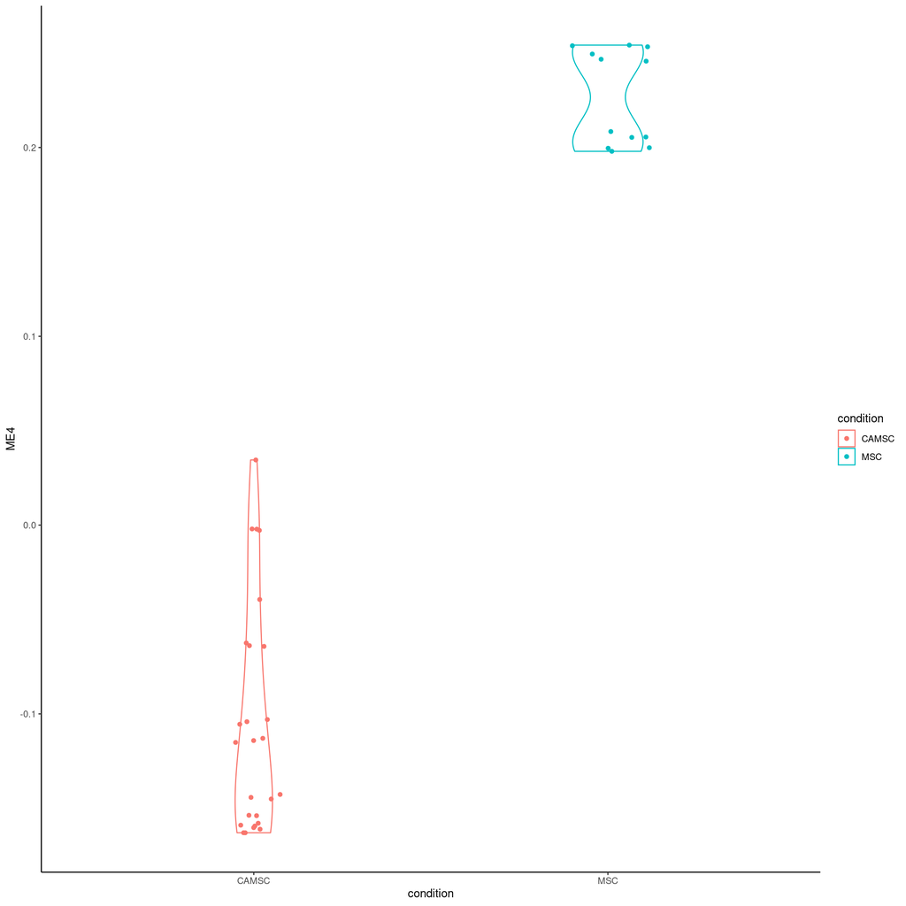

Extract genes for module 4 and plot them on a heatmap

```
## [1] 1342
```

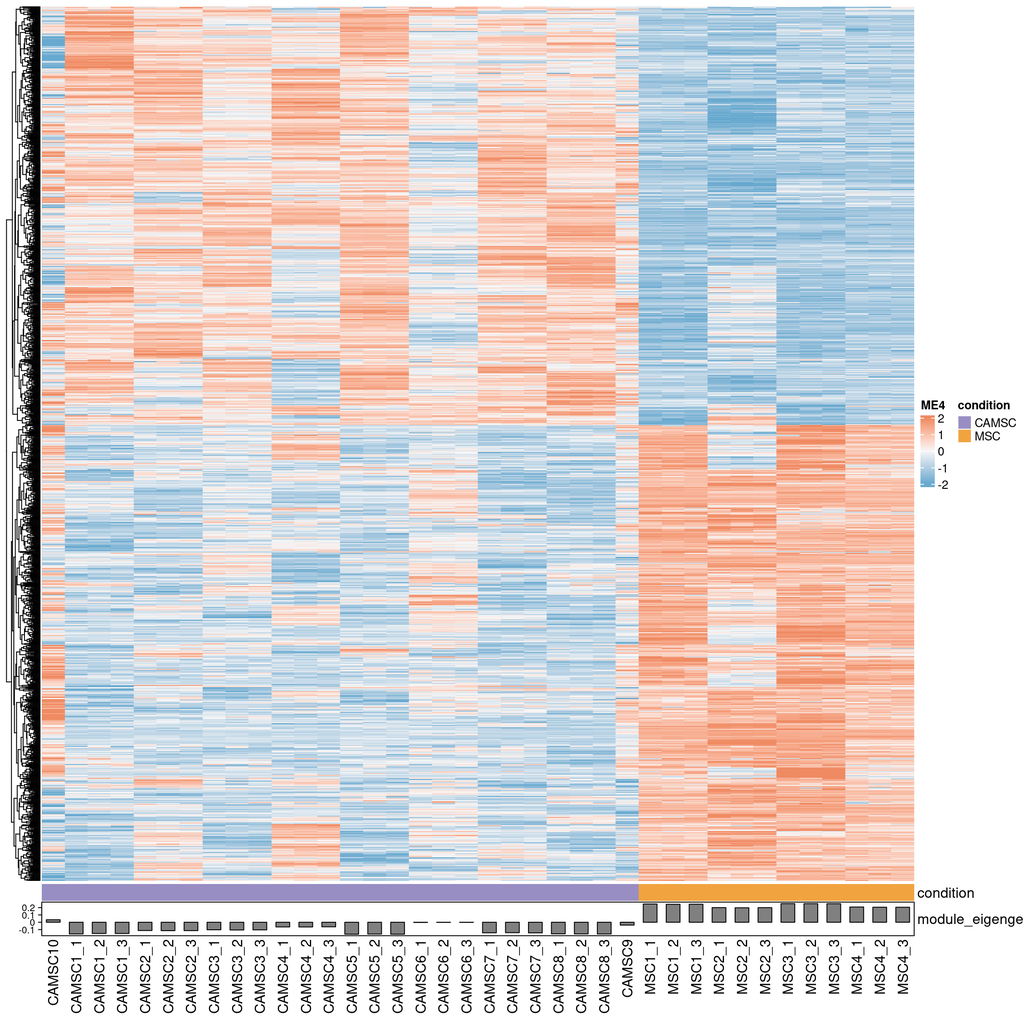

### ME5

Violin plot for eigengenes distribution in different condition

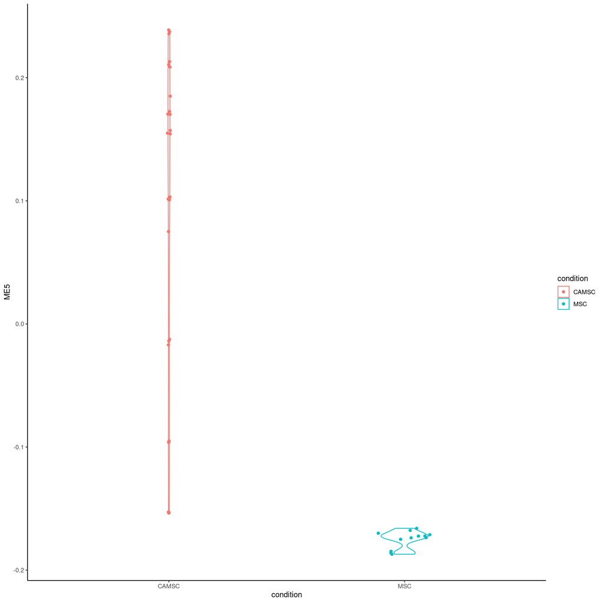

Extract genes for module 5 and plot them on a heatmap

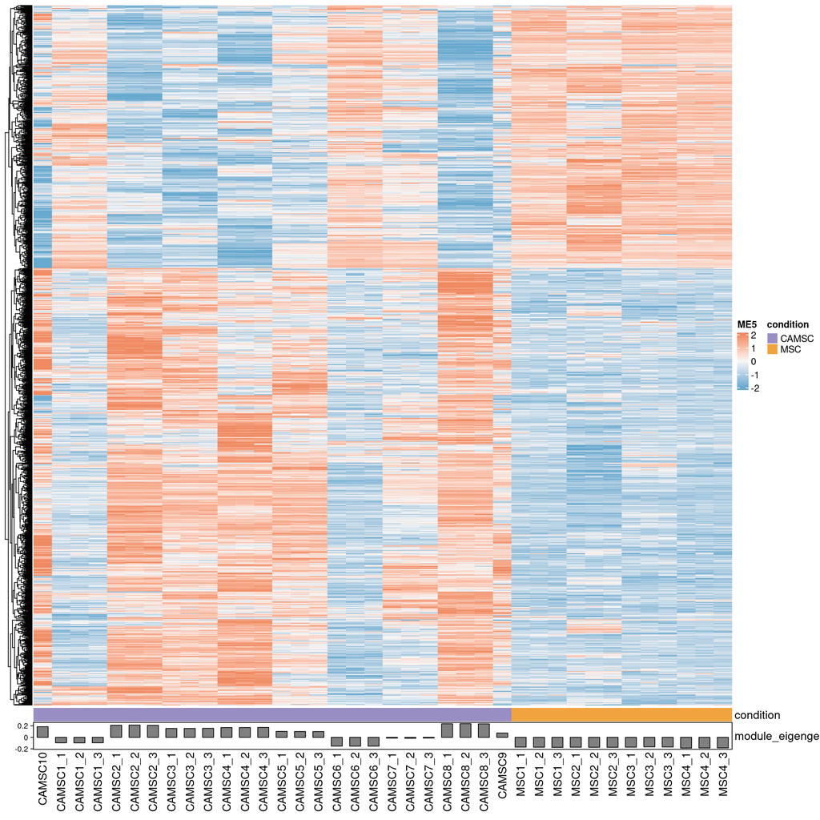

### ME16

Violin plot for eigengenes distribution in different condition

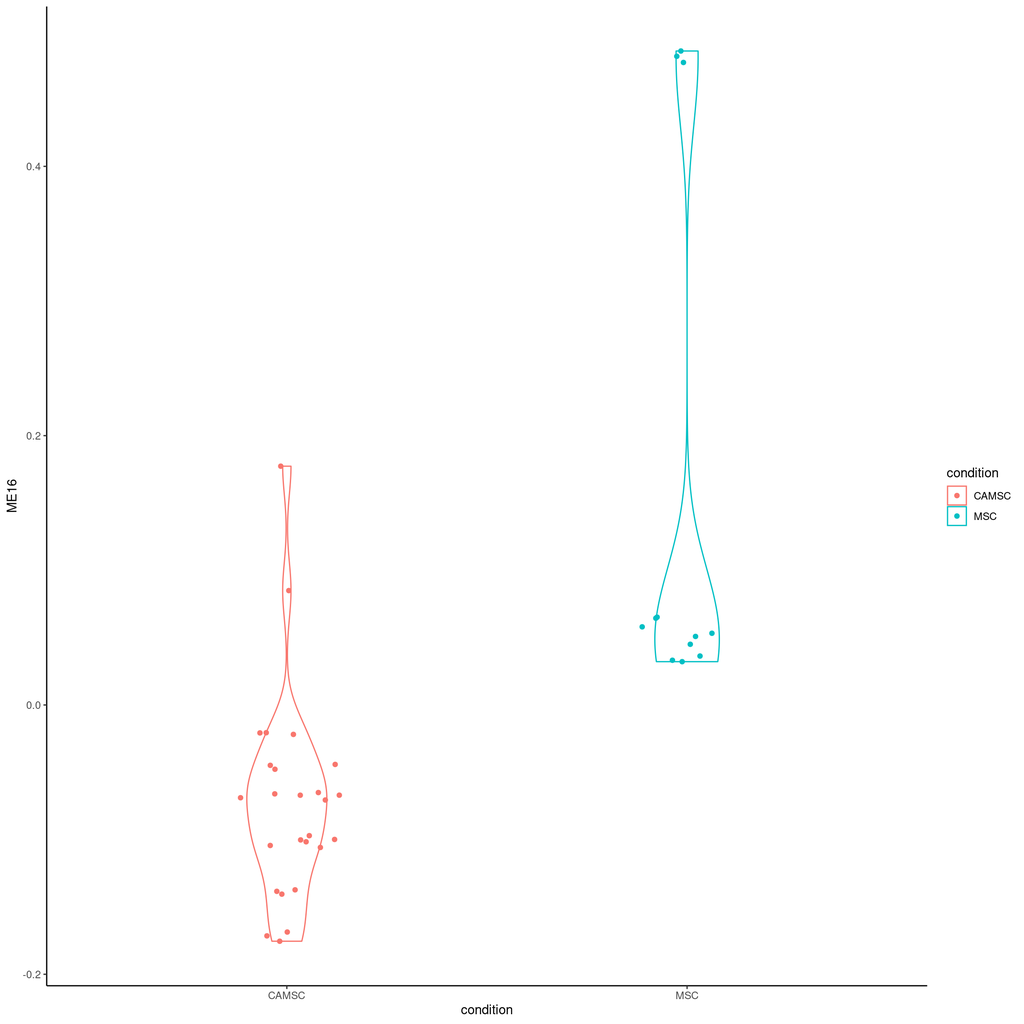

Extract genes for module 16 and plot them on a heatmap

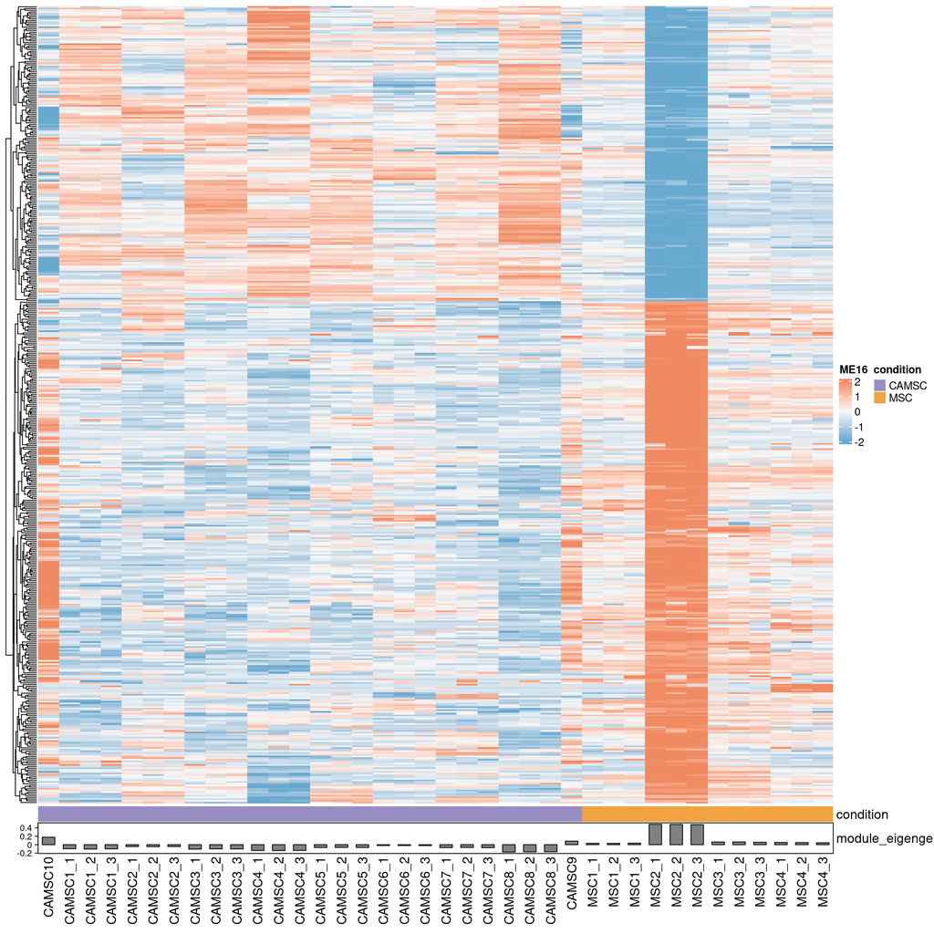